# lab4

Tiffany Nguyen

2025-02-07

```r
library(Intro2R)
dird="/Users/tiffanynguyen/Documents/College/Sophomore/Spring_2025/Applied_Statistical_Methods/MATH4753nguy0850/labs/lab4/DATAxls/"
myread=function(csv){
  fl=paste(dird,csv,sep="")
  read.table(fl,header=TRUE,sep=",")
}
```

# Task 1

```r
getwd()
```

```
## [1] "/Users/tiffanynguyen/Documents/College/Sophomore/Spring_2025/Applied_Statistical_Methods/MATH4753nguy0850/labs/lab4"
```

# Task 2

```r
spruce.df=myread("SPRUCE.csv")
tail(spruce)
```

```
## # A tibble: 6 × 2
##   BHDiameter Height
##        <dbl>  <dbl>
## 1       17.7   19.9
## 2       20.7   19.4
## 3       21     20.4
## 4       13.3   15.5
## 5       15.9   17.6
## 6       22.9   19.2
```

# Task 3

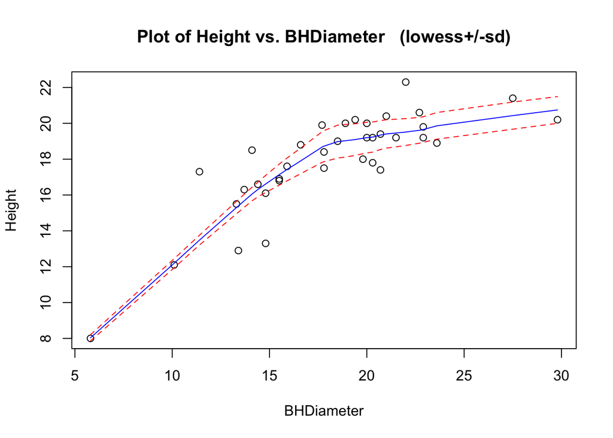

```r
library(s20x)

# lowess smoother scatter plot
trendscatter(Height ~ BHDiameter, data = spruce.df, f = 0.5)
```

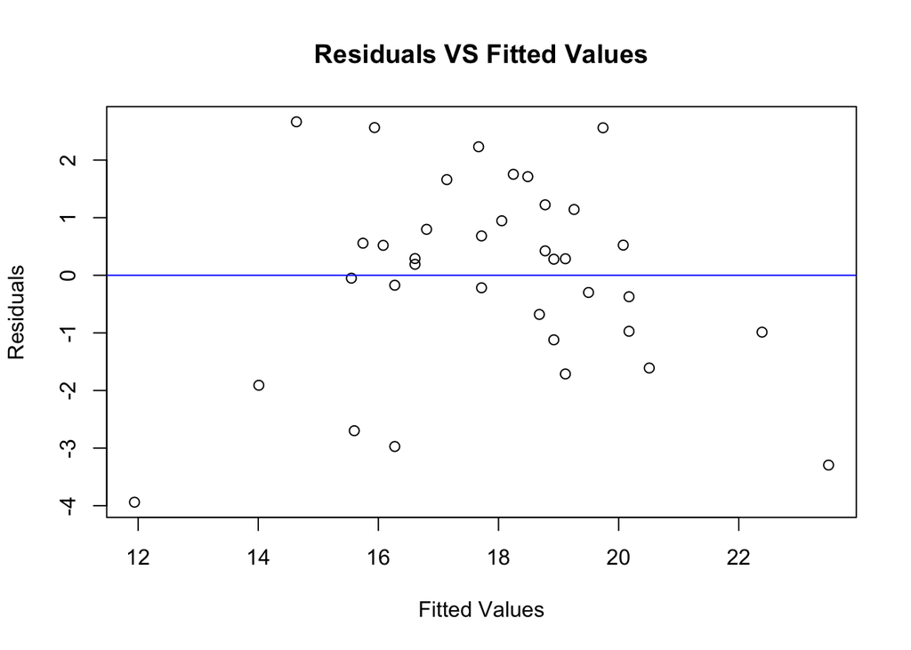

```r
# made linear model object
spruce.lm = lm(Height~BHDiameter,data=spruce.df)

#finding residuals and fitted values
height.res = residuals(spruce.lm)
height.fit = fitted(spruce.lm)

# plot residuals vs fitted values
plot(height.fit, height.res,
     xlab = "Fitted Values",
     ylab = "Residuals",
     main = "Residuals VS Fitted Values")
abline(h = 0, col = "blue")
```

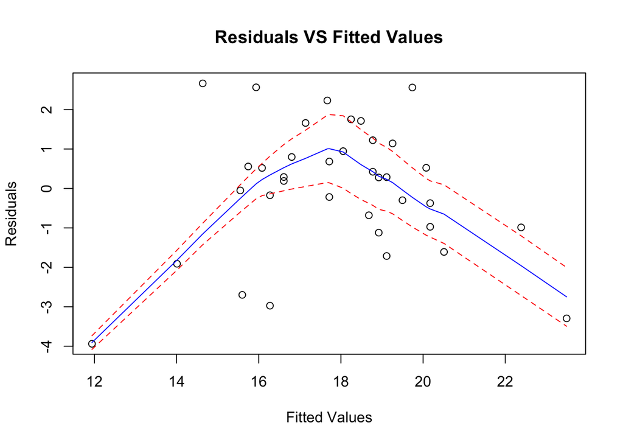

```r
# plot residuals vs fitted values using trendscatter
trendscatter(height.fit, height.res,
             xlab = "Fitted Values",
             ylab = "Residuals",
             main = "Residuals VS Fitted Values")
```

The line created by the fitted and residual values created a parabolic shape, whereas the previous trendsetter function curve created a more linear shape.

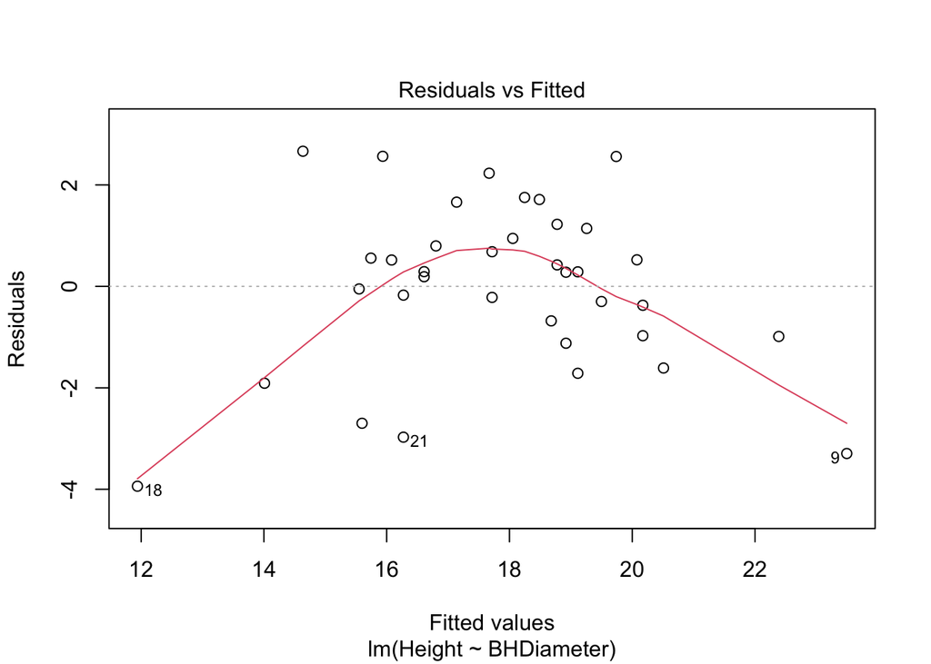

```r
# residual plot  for spruce.lm
plot(spruce.lm, which = 1)
```

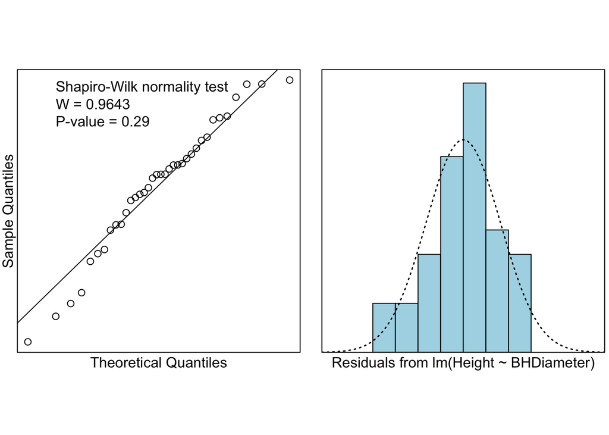

```r
# check normality
normcheck(spruce.lm, shapiro.wilk = TRUE)
```

The p-value for the Shapiro-Wilk’s test is 0.29. In this case, the NULL hypothesis is that the residuals are normally distributed since 0.29 > 0.05.

# Task 4

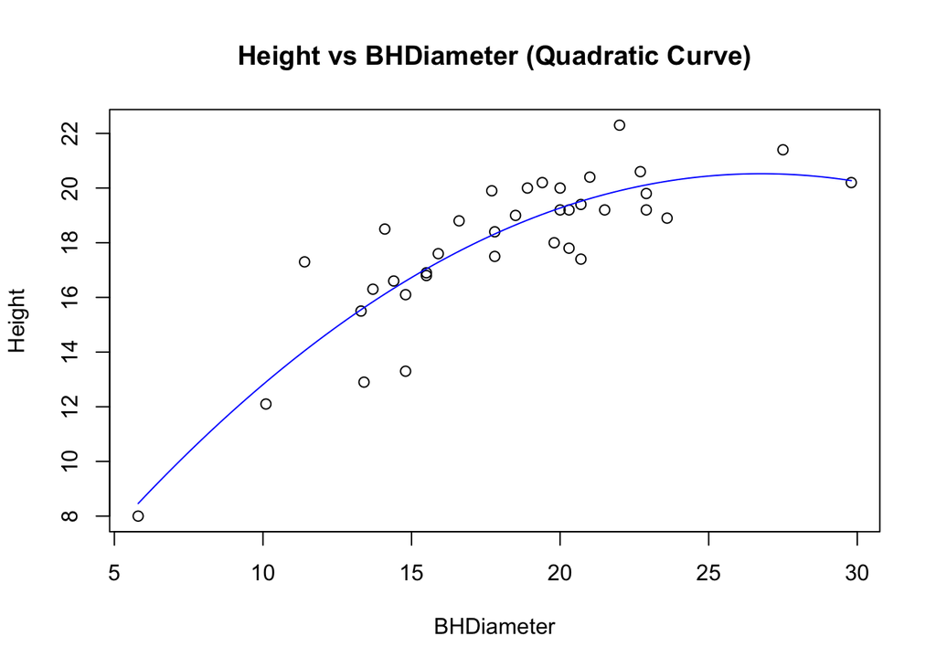

```r
# fitting quadratic to points
quad.lm <- lm(Height ~ BHDiameter + I(BHDiameter^2), data = spruce.df)

# scatter plot of Height vs BHDiameter with quadratic curve
plot(spruce.df$BHDiameter, spruce.df$Height,
     xlab = "BHDiameter",
     ylab = "Height",
     main = "Height vs BHDiameter (Quadratic Curve)")

BHDiameter_seq <- seq(min(spruce.df$BHDiameter), max(spruce.df$BHDiameter), length.out = 100)

height_pred <- predict(quad.lm, newdata = data.frame(BHDiameter = BHDiameter_seq))
lines(BHDiameter_seq, height_pred, col = "blue")
```

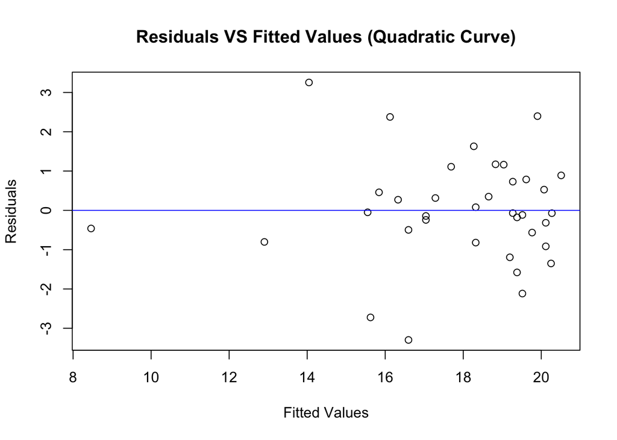

```r
# made vector of fitted values
quad.fit <- fitted(quad.lm)

# plot of residuals vs fitted values
plot(quad.fit, residuals(quad.lm),
     xlab = "Fitted Values",
     ylab = "Residuals",
     main = "Residuals VS Fitted Values (Quadratic Curve)")
abline(h = 0, col = "blue")
```

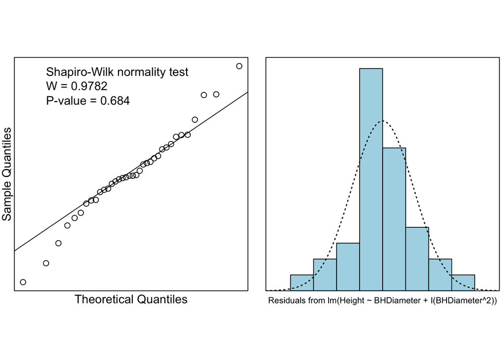

```r
# QQ plot using normcheck()
normcheck(quad.lm, shapiro.wilk = TRUE)
```

The p-value in the Shapiro-Wilk test is 0.684. I conclude that applying the quadratic model to predict the height of the spruce trees is reasonable because residuals do not suggest a trend and the residuals are normally distributed (p-value > 0.05).

# Task 5

```r
# summary of quad.lm
summary(quad.lm)
```

```
##
## Call:
## lm(formula = Height ~ BHDiameter + I(BHDiameter^2), data = spruce.df)
##
## Residuals:
##     Min      1Q  Median      3Q     Max
## -3.2966 -0.6245 -0.0707  0.7442  3.2541
##
## Coefficients:
##                  Estimate Std. Error t value Pr(>|t|)
## (Intercept)      0.860896   2.205022   0.390 0.698731
## BHDiameter       1.469592   0.243786   6.028 8.88e-07 ***
## I(BHDiameter^2) -0.027457   0.006635  -4.138 0.000227 ***
## ---
## Signif. codes:  0 '***' 0.001 '**' 0.01 '*' 0.05 '.' 0.1 ' ' 1
##
## Residual standard error: 1.382 on 33 degrees of freedom
## Multiple R-squared:  0.7741, Adjusted R-squared:  0.7604
## F-statistic: 56.55 on 2 and 33 DF,  p-value: 2.182e-11
```

$$\begin{eqnarray}
\hat{\beta_0} &=& 0.860896 \\
\hat{\beta_1} &=& 1.469592 \\
\hat{\beta_2} &=& -0.027457 \\
\end{eqnarray}$$

```r
# interval estimates for the b
confint(quad.lm)
```

```
##                       2.5 %      97.5 %
## (Intercept)     -3.62525427  5.34704588
## BHDiameter       0.97360659  1.96557775
## I(BHDiameter^2) -0.04095645 -0.01395806
```

Equation of the fitted line:
$$\begin{eqnarray}
\hat{y} &=& 0.86089580 + 1.46959217 x - 0.02745726x^2
\end{eqnarray}$$

```r
# predict Height of spruce
predict(quad.lm, pred = data.frame(BHDiameter = c(15, 18, 20)))
```

```
##         1         2         3         4         5         6         7         8
## 18.828182 17.690005 17.042969 17.042969 19.037171 15.840856 19.269837 20.510131
##         9        10        11        12        13        14        15        16
## 20.271601 19.378756 19.194478 20.115697 19.378756 16.123368 19.269837 12.902862
##        17        18        19        20        21        22        23        24
## 19.902612  8.460868 20.250678 19.516294 16.596623 18.320080 20.072189 14.045902
##        25        26        27        28        29        30        31        32
## 18.651105 16.329487 19.765011 15.623206 16.596623 18.320080 18.270594 19.516294
##        33        34        35        36
## 19.613682 15.549558 17.285943 20.115697
```

$$\begin{eqnarray}
Multiple R^2 &=& 0.7741 \\
Adjusted R^2 &=& 0.7604 \\
\end{eqnarray}$$

```r
# determine which R squared model is better
linear.lm <- lm(Height ~ BHDiameter, data = spruce.df)
anova(linear.lm, quad.lm)
```

```
## Analysis of Variance Table
##
## Model 1: Height ~ BHDiameter
## Model 2: Height ~ BHDiameter + I(BHDiameter^2)
##   Res.Df    RSS Df Sum of Sq      F    Pr(>F)
## 1     34 95.703
## 2     33 63.007  1    32.696 17.125 0.0002269 ***
## ---
## Signif. codes:  0 '***' 0.001 '**' 0.01 '*' 0.05 '.' 0.1 ' ' 1
```

In this case, the quadratic model has a higher R^2 and adjusted R^2 value compared to the lowess model, which explains the variability in the Height. According to ANOVA, the p-value (< 0.001) means the quadratic term was a significant improvement in terms of prediction compared to the linear model. Overall, the quadratic model is more appropriate for predicting the height of spruce trees.

```r
yhat=fitted(quad.lm)

# TSS calculation
TSS=with(spruce,sum((Height-mean(Height))^2))
print(paste("TSS: ", TSS))
```

```
## [1] "TSS:  278.9475"
```

```r
# MSS calculation
MSS=with(spruce,sum((yhat-mean(Height))^2))
print(paste("MSS: ", MSS))
```

```
## [1] "MSS:  215.940665987179"
```

```r
# RSS calculation
RSS=with(spruce,sum((Height-yhat)^2))
print(paste("RSS: ", RSS))
```

```
## [1] "RSS:  63.0068340128209"
```

```r
# MSS/TSS calculation
print(paste("MSS/TSS (aka R^2): ", MSS/TSS))
```

```
## [1] "MSS/TSS (aka R^2):  0.774126550649061"
```

# Task 6

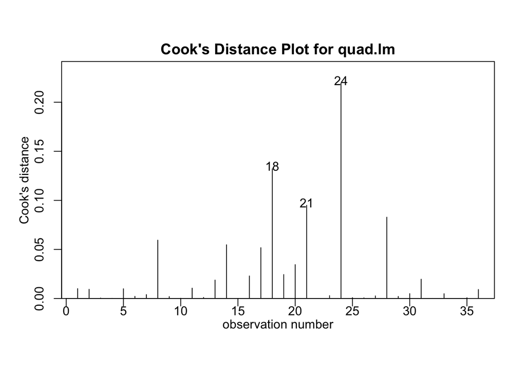

```r
# cooks plot
cooks20x(quad.lm, main="Cook's Distance Plot for quad.lm")
```

Cook’s distance measures how much each data point influences the results of the regression analysis. This method of measurement also helps determine and identify outliers, or points that have a large effect on the estimation of the regression coefficients.

```r
cdist <- cooks.distance(quad.lm)
which.max(cdist)
```

```
## 24
## 24
```

In this case, the cooks distance for the quadratic model and data tells me that the 24th data point has the most influence on the regression analysis.

```r
# same quadratic model after removing highest cooks distance
spruce.df2 <- spruce.df[-24,]
quad2.lm <- lm(Height ~ BHDiameter + I(BHDiameter^2), data = spruce.df2)

summary(quad2.lm)
```

```
##
## Call:
## lm(formula = Height ~ BHDiameter + I(BHDiameter^2), data = spruce.df2)
##
## Residuals:
##      Min       1Q   Median       3Q      Max
## -3.11233 -0.48227  0.01253  0.71727  2.59146
##
## Coefficients:
##                  Estimate Std. Error t value Pr(>|t|)
## (Intercept)     -0.341500   2.068479  -0.165     0.87
## BHDiameter       1.564793   0.226102   6.921 7.78e-08 ***
## I(BHDiameter^2) -0.029242   0.006114  -4.782 3.74e-05 ***
## ---
## Signif. codes:  0 '***' 0.001 '**' 0.01 '*' 0.05 '.' 0.1 ' ' 1
##
## Residual standard error: 1.266 on 32 degrees of freedom
## Multiple R-squared:  0.8159, Adjusted R-squared:  0.8044
## F-statistic: 70.91 on 2 and 32 DF,  p-value: 1.74e-12
```

```r
summary(quad.lm)
```

```
##
## Call:
## lm(formula = Height ~ BHDiameter + I(BHDiameter^2), data = spruce.df)
##
## Residuals:
##     Min      1Q  Median      3Q     Max
## -3.2966 -0.6245 -0.0707  0.7442  3.2541
##
## Coefficients:
##                  Estimate Std. Error t value Pr(>|t|)
## (Intercept)      0.860896   2.205022   0.390 0.698731
## BHDiameter       1.469592   0.243786   6.028 8.88e-07 ***
## I(BHDiameter^2) -0.027457   0.006635  -4.138 0.000227 ***
## ---
## Signif. codes:  0 '***' 0.001 '**' 0.01 '*' 0.05 '.' 0.1 ' ' 1
##
## Residual standard error: 1.382 on 33 degrees of freedom
## Multiple R-squared:  0.7741, Adjusted R-squared:  0.7604
## F-statistic: 56.55 on 2 and 33 DF,  p-value: 2.182e-11
```

This new model shows improvement:

- the new quadratic has a higher R^2 value (0.8159 > 0.7741), indicating a better overall fit for the model
- the adjusted R^2 value is also higher, which means the quadratic model is more accurate after removing the highest cooks distance.
- the residual standard error decreased (1.266 < 1.382), which means the new quadratic is more accurate with predictions

Overall, the removal of the highest cook point improved the accuracy and representation of the relationship between spruce tree Height and BHDiameter.

# Task 7

Prove using latex that $y = \beta_0 +\beta_1 x + \beta_2 (x - x_k) I (x > x_k)$ where $I()$ is 1 when $x > x_k$ and 0 else.

We have 2 lines with point $x_k$ in common
$$\ell_1 : y = \beta_0 + \beta_1 x$$
$$\ell_2 : y = \beta_0 + \beta_1 x
+ (\beta_1 + \beta_2)x$$
Set the equations equal to one another to determine the value of $\delta$:
$$y_k=\beta_0+\beta_1x_k=\beta_0+\delta+(\beta_1+\beta_2)x_k$$
Distribute $x_k$:
$$\beta_0+\beta_1x_k=\beta_0+\delta+\beta_1x_k+\beta_2x_k$$
Divide both sides by $\beta_0$ and $\beta_1x$:
$$0=\delta+\beta_2x_k$$
So we get:
$$\delta=-\beta_2x_k$$
By determining $\delta$, we can now break down $\ell_2$:
$$\ell_2:y=\beta_0+\delta+(\beta_1+\beta_2)x$$
Substitute $\delta$ using the previous derived value:
$$\beta_0-\beta_2x_k+(\beta_1+\beta_2)x$$
Distribute $x$:
$$\beta_0-\beta_2x_k+\beta_1x+\beta_2x$$
Do some shuffling around:
$$\beta_0+\beta_1x+\beta_2x-\beta_2x_k$$
Do some factoring:
$$\beta_0+\beta_1x+\beta_2(x-x_k)$$
This leaves us with $\ell_2$ in terms of $\ell_1$. Therefore,
$$y=\beta_0+\beta_1x+\beta_2(x-x_k)I(x>x_k)$$
This fulfills $I()$ being 1 if $x > x_k$ and 0 otherwise.

```r
#piecewise linear model
sp2.df = within(spruce, X <- (BHDiameter - 18) * (BHDiameter > 18)) # this makes a new variable and places it within the same df

lmp = lm(Height ~ BHDiameter + X, data = sp2.df)
tmp = summary(lmp)
names(tmp)
```

```
##  [1] "call"          "terms"         "residuals"     "coefficients"
##  [5] "aliased"       "sigma"         "df"            "r.squared"
##  [9] "adj.r.squared" "fstatistic"    "cov.unscaled"
```

```r
myf = function(x,coef) {
  coef[1] + coef[2] * (x) + coef[3] * (x-18) * (x-18>0)
}
plot(spruce, main="Piecewise regression")
myf(0, coef = tmp$coefficients[,"Estimate"])
```

```
## (Intercept)
##    4.499237
```

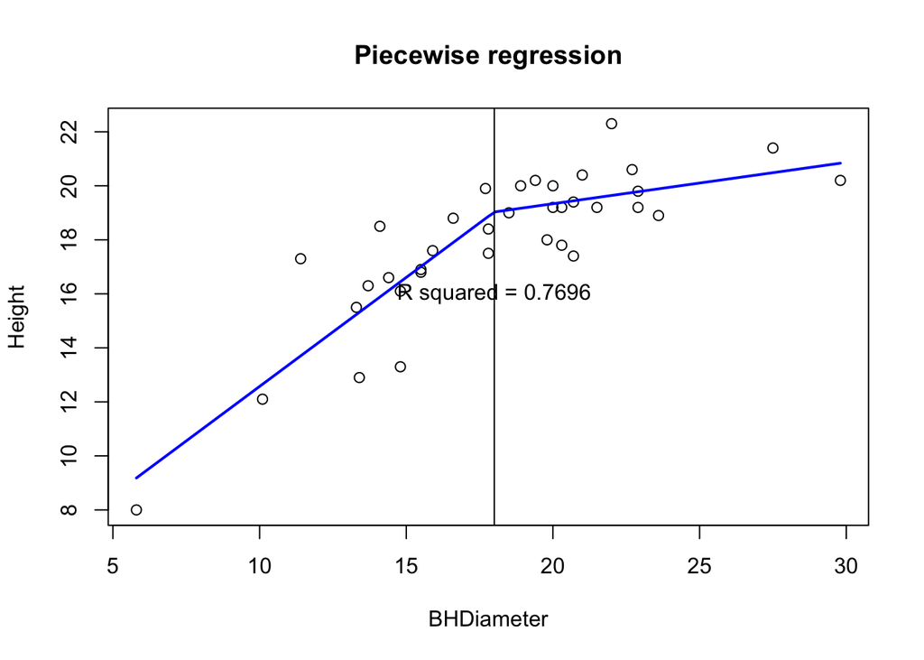

```r
curve(myf(x, coef = tmp$coefficients[,"Estimate"]), add=TRUE, lwd=2, col="blue")
abline(v=18)
text(18, 16, paste("R squared =", round(tmp$r.squared, 4)))
```

# Task 8

```r
MATH4753nguy0850::myread("SPRUCE.csv", "/Users/tiffanynguyen/Documents/College/Sophomore/Spring_2025/Applied_Statistical_Methods/MATH4753nguy0850/labs/lab4/DATAxls/")
```

```
##    BHDiameter Height
## 1        18.9   20.0
## 2        16.6   18.8
## 3        15.5   16.8
## 4        15.5   16.9
## 5        19.4   20.2
## 6        13.7   16.3
## 7        20.0   20.0
## 8        27.5   21.4
## 9        29.8   20.2
## 10       20.3   19.2
## 11       19.8   18.0
## 12       22.9   19.8
## 13       20.3   17.8
## 14       14.1   18.5
```

[output cut: 22 more lines]

This function reads a csv file nice and prettily!